# Weather EDA

Eric Breton

April 15, 2019

```r
install.packages("XML")
```

[output not shown]

```r
install.packages("RCurl")
```

[output not shown]

```r
install.packages("RVest")
```

[output not shown]

```r
install.packages("reshape2")
```

[output not shown]

```r
install.packages("tidyr")
```

[output not shown]

```r
install.packages("data.table")
```

[output not shown]

```r
install.packages("stringi")
```

[output not shown]

```r
install.packages("sqldf")
```

[output not shown]

```r
install.packages("dplyr")
```

[output not shown]

```r
install.packages('corrplot')
```

[output not shown]

```r
install.packages("ggplot2")
```

[output not shown]

```r
install.packages("factoextra")
```

[output not shown]

```r
install.packages("cowplot")
```

[output not shown]

```r
install.packages("cluster")
```

[output not shown]

```r
install.packages("NbClust")
```

[output not shown]

```r
library(NbClust)
library(cluster)
```

```r
library(cowplot)
library(factoextra)
library(corrplot)
library(ggplot2)
library(XML)
library(RCurl)
library(rvest)
library(dplyr)
library(reshape2)
library(tidyr)
library(data.table)
library(stringi)
library(sqldf)
library (lattice)
library(ggplot2)
library(tidyverse)
library(kableExtra)
setwd("C:/Users/ebret/Desktop/Practicum")
df<-fread("weather_Data_reduced.csv",stringsAsFactors = FALSE)
#View(df)
#pull any valid baseball months
#weed out bad data results for pressure, these were obvious so I pulled them out
#sqldf('select max(pressure) from df')
head(df)
```

| V1 | Date | temp | pressure | humidity | wind_speed | wind_deg | clouds_all | weather_description | Day_Night |
| --- | --- | --- | --- | --- | --- | --- | --- | --- | --- |
| 1 | 2012-10-02 | 63.36 | 1024 | 0 | 0.00 | 73 | 3 | sky is clear | D |
| 2 | 2012-10-03 | 54.61 | 1024 | 36 | 0.00 | 0 | 20 | few clouds | N |
| 3 | 2012-10-03 | 79.11 | 1015 | 9 | 4.47 | 360 | 20 | few clouds | D |
| 4 | 2012-10-04 | 64.02 | 1014 | 11 | 0.00 | 0 | 20 | few clouds | N |
| 5 | 2012-10-04 | 78.24 | 1013 | 7 | 13.42 | 270 | 20 | few clouds | D |
| 6 | 2012-10-05 | 45.14 | 1022 | 0 | 0.00 | 312 | 11 | sky is clear | D |

```r
wd_filtered<-sqldf('select * from df where strftime("%m", Date) between "04" and "09" and pressure not in ("0","9985") ')
head(wd_filtered)
```

|  | V1 | Date | temp | pressure | humidity | wind_speed | wind_deg | clouds_all | weather_description | Day_Night |
| --- | --- | --- | --- | --- | --- | --- | --- | --- | --- | --- |
| 1 | 369 | 2013-04-01 | 45.93 | 1020 | 0 | 6.71 | 0 | 28 | scattered clouds | N |
| 2 | 370 | 2013-04-01 | 67.46 | 1015 | 10 | 6.71 | 60 | 20 | few clouds | D |
| 3 | 371 | 2013-04-02 | 53.06 | 1016 | 16 | 2.24 | 80 | 5 | sky is clear | N |
| 4 | 372 | 2013-04-02 | 49.96 | 1018 | 49 | 11.18 | 330 | 75 | broken clouds | D |
| 5 | 373 | 2013-04-03 | 44.65 | 1014 | 0 | 6.71 | 302 | 50 | scattered clouds | N |
| 6 | 374 | 2013-04-03 | 37.90 | 1017 | 0 | 2.24 | 348 | 71 | light rain | D |

```r
#Combining my day with date so that I get a primary key
wd_filtered<-sqldf('select distinct(Date) as Date,temp,pressure,humidity,wind_speed,wind_deg,clouds_all,Day_Night from wd_filtered')
wd1<-sqldf('select Day_Night||Date,temp,pressure,humidity,wind_speed ,wind_deg,clouds_all from wd_filtered')
#View(wd)
#head(wd1)
```

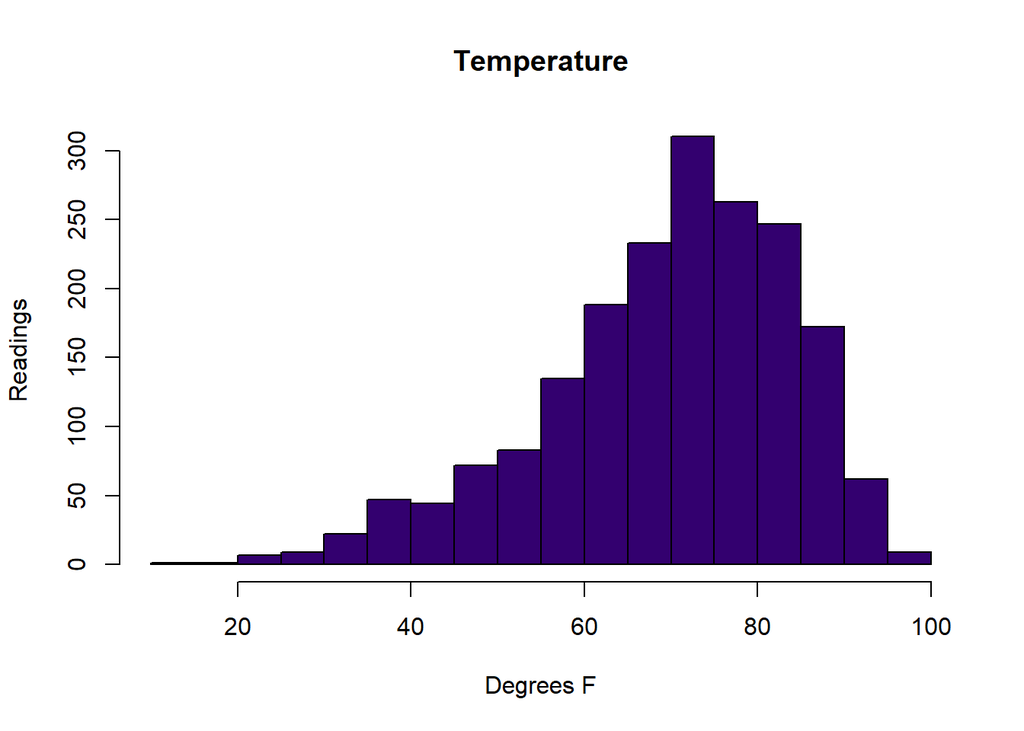

```r
hist(wd1$temp,main="Temperature",xlab="Degrees F",ylab="Readings",breaks=15,col="#33006F")
```

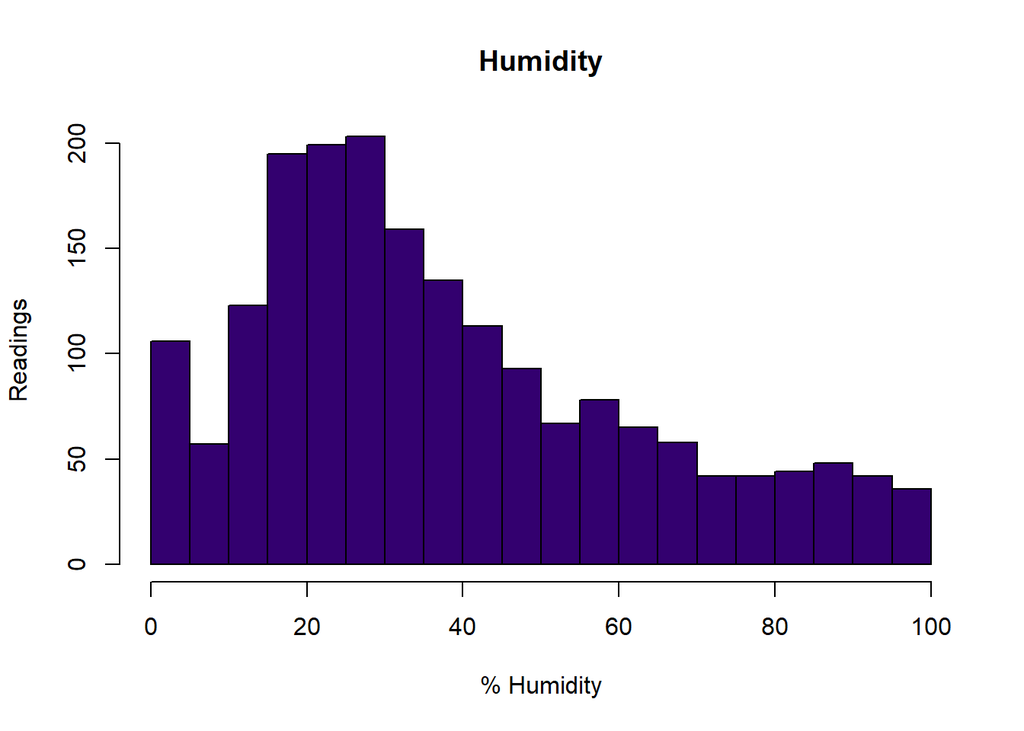

```r
hist(wd1$humidity,main="Humidity",xlab="% Humidity",ylab="Readings",breaks=15,col="#33006F")
```

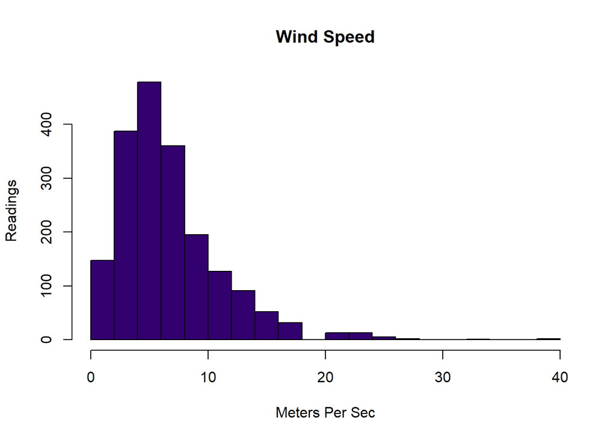

```r
hist(wd1$wind_speed,main="Wind Speed",xlab="Meters Per Sec",ylab="Readings",breaks=15,col="#33006F")
```

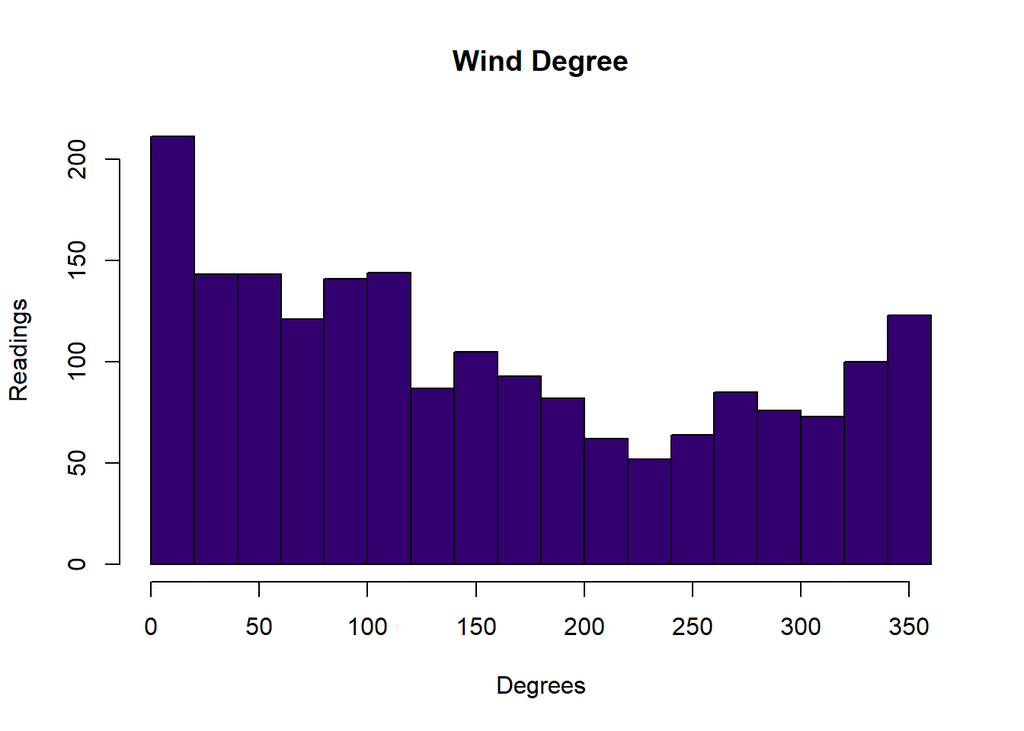

```r
hist(wd1$wind_deg,main="Wind Degree",xlab="Degrees",ylab="Readings",breaks=15,col="#33006F")
```

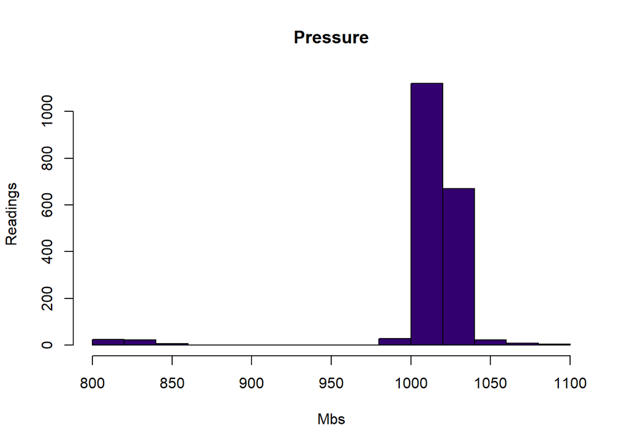

```r
hist(wd1$pressure,main="Pressure",xlab="Mbs",ylab="Readings",breaks=15,col="#33006F")
```

My results show that for my temperature and pressure measures the data is fairly normally distributed being skewed left. The opposite is true for wind speed and humidity which is skewed to the right. Wind degree has much less of a bell shaped curve, but this is also a bit different from the others as it uses a 360 degree scale to simulate the cardinal directions.

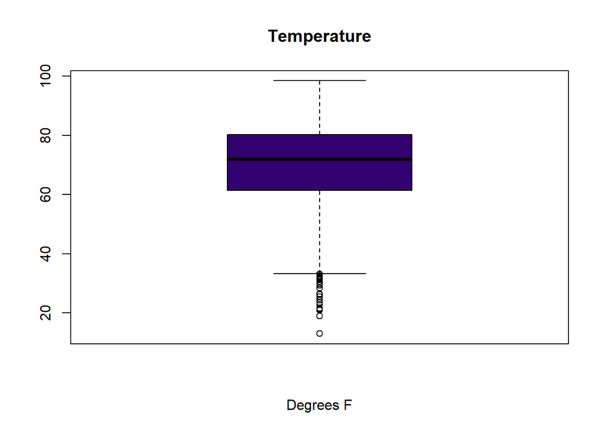

```r
boxplot(wd1$temp,main="Temperature",xlab="Degrees F",col="#33006F")
```

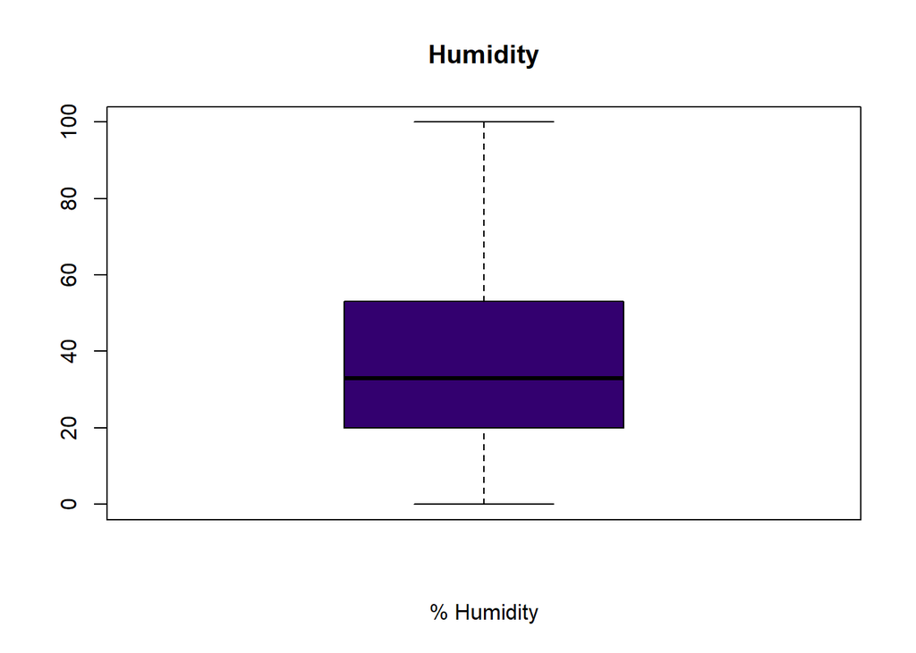

```r
boxplot(wd1$humidity,main="Humidity",xlab="% Humidity",col="#33006F")
```

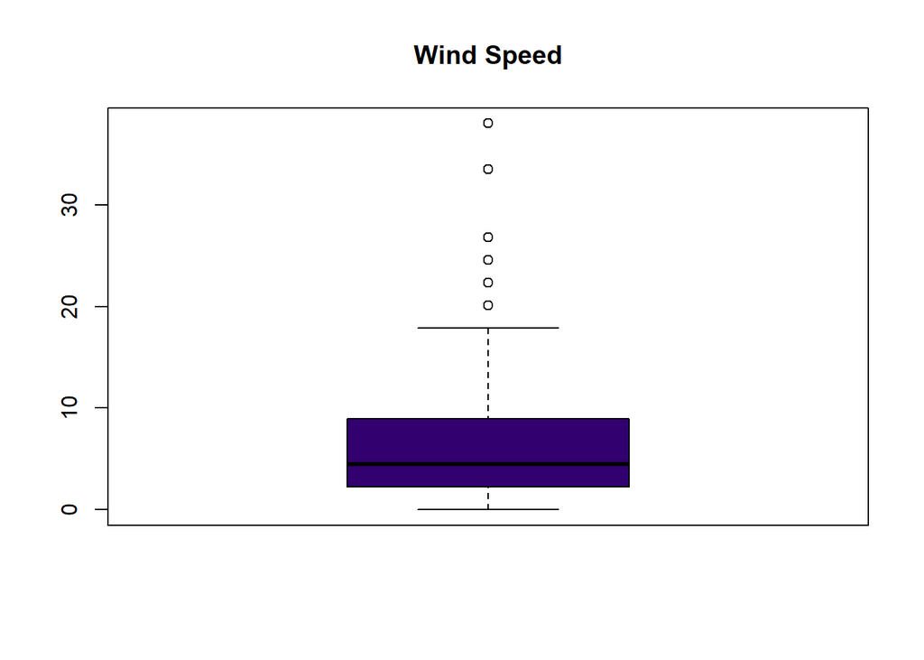

```r
boxplot(wd1$wind_speed,main="Wind Speed",col="#33006F")
```

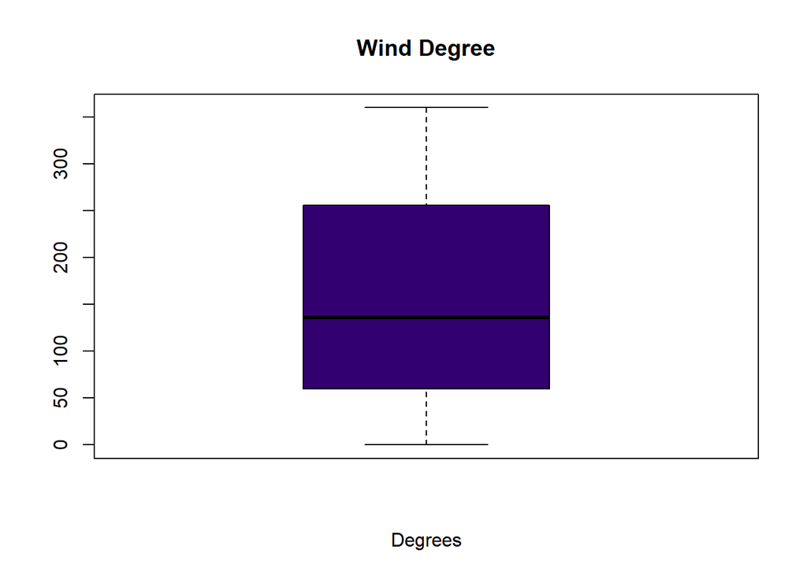

```r
boxplot(wd1$wind_deg,main="Wind Degree",xlab="Degrees",col="#33006F")
```

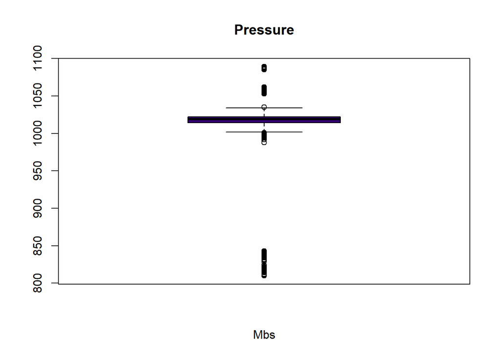

```r
boxplot(wd1$pressure,main="Pressure",xlab="Mbs",col="#33006F")
```

```r
summary(wd1)
```

```
##  Day_Night||Date         temp          pressure       humidity
##  Length:1905        Min.   :12.97   Min.   : 810   Min.   :  0.00
##  Class :character   1st Qu.:61.39   1st Qu.:1014   1st Qu.: 20.00
##  Mode  :character   Median :71.87   Median :1019   Median : 33.00
##                     Mean   :69.71   Mean   :1013   Mean   : 38.49
##                     3rd Qu.:80.26   3rd Qu.:1022   3rd Qu.: 53.00
##                     Max.   :98.46   Max.   :1089   Max.   :100.00
##    wind_speed        wind_deg       clouds_all
##  Min.   : 0.000   Min.   :  0.0   Min.   :  0.0
##  1st Qu.: 2.240   1st Qu.: 60.0   1st Qu.:  1.0
##  Median : 4.470   Median :136.0   Median : 40.0
##  Mean   : 6.316   Mean   :157.1   Mean   : 40.9
##  3rd Qu.: 8.950   3rd Qu.:256.0   3rd Qu.: 75.0
##  Max.   :38.030   Max.   :360.0   Max.   :100.0
```

```r
#wd_day
#View(df)
# set rownames and remove erronious day night as I am dividing the data into days vs night
wd <- wd1%>% select(-`Day_Night||Date`)
#View(wd)
#Set all my measures to numeric so that they can be scaled
wd$pressure=as.numeric(wd$pressure)
wd$humidity=as.numeric(wd$humidity)
wd$wind_deg=as.numeric(wd$wind_deg)
wd$wind_speed=as.numeric(wd$wind_speed)
wd$clouds_all=as.numeric(wd$clouds_all)
wd <- as_tibble(wd)
#View(wd)
#str(wd)
#Scale my Data
wd_scaled <- scale(wd)
#Add back my row names
rownames(wd_scaled) <- wd1$`Day_Night||Date`
View(wd_scaled)
```

I will run clustering analysis for a large number of clusters than test the different outcomes using the elbow method and NbClust.

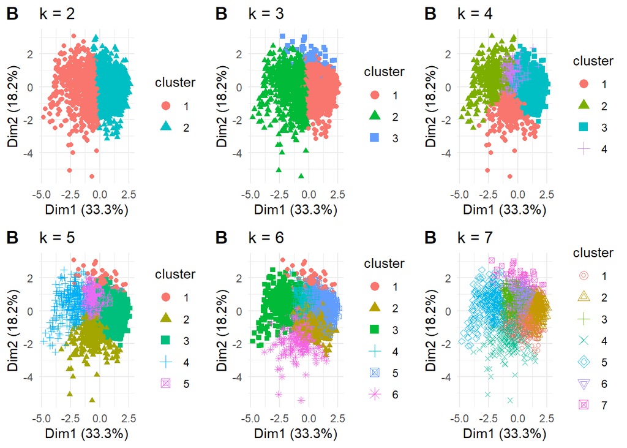

```r
#Setting my seed so my results will be reproducable
set.seed=42
#in this step I create a way in which I will be able to run multiple numbers of clusters at the same time and the check them all togther. This makes things much more efficient for me.
kmean_calc <- function(df, ...){
  kmeans(df, scaled = ..., nstart = 25)
}
km2 <- kmean_calc(wd_scaled, 2)
km3 <- kmean_calc(wd_scaled, 3)
km4 <- kmeans(wd_scaled, 4)
km5 <- kmeans(wd_scaled, 5)
km6 <- kmeans(wd_scaled, 6)
km7 <- kmeans(wd_scaled, 7)
km8 <- kmeans(wd_scaled, 8)
km9 <- kmeans(wd_scaled, 9)
km10 <- kmeans(wd_scaled, 10)
km11 <- kmeans(wd_scaled, 11)

#Plotting my viusals on the plot grid will give me a visual indication of how my clusters look.
p1 <- fviz_cluster(km2, data = wd_scaled,geom = "point", frame.type = "ellipse") + theme_minimal() + ggtitle("k = 2")
p2 <- fviz_cluster(km3, data = wd_scaled,geom = "point", frame.type = "ellipse") + theme_minimal() + ggtitle("k = 3")
p3 <- fviz_cluster(km4, data = wd_scaled,geom = "point", frame.type = "ellipse") + theme_minimal() + ggtitle("k = 4")
p4 <- fviz_cluster(km5, data = wd_scaled,geom = "point", frame.type = "ellipse") + theme_minimal() + ggtitle("k = 5")
p5 <- fviz_cluster(km6, data = wd_scaled,geom = "point", frame.type = "ellipse") + theme_minimal() + ggtitle("k = 6")
p6 <- fviz_cluster(km7, data = wd_scaled,geom = "point", frame.type = "ellipse") + theme_minimal() + ggtitle("k = 7")
plot_grid(p1, p2, p3, p4, p5, p6, labels = c("B", "B", "B", "B", "B", "B"))
```

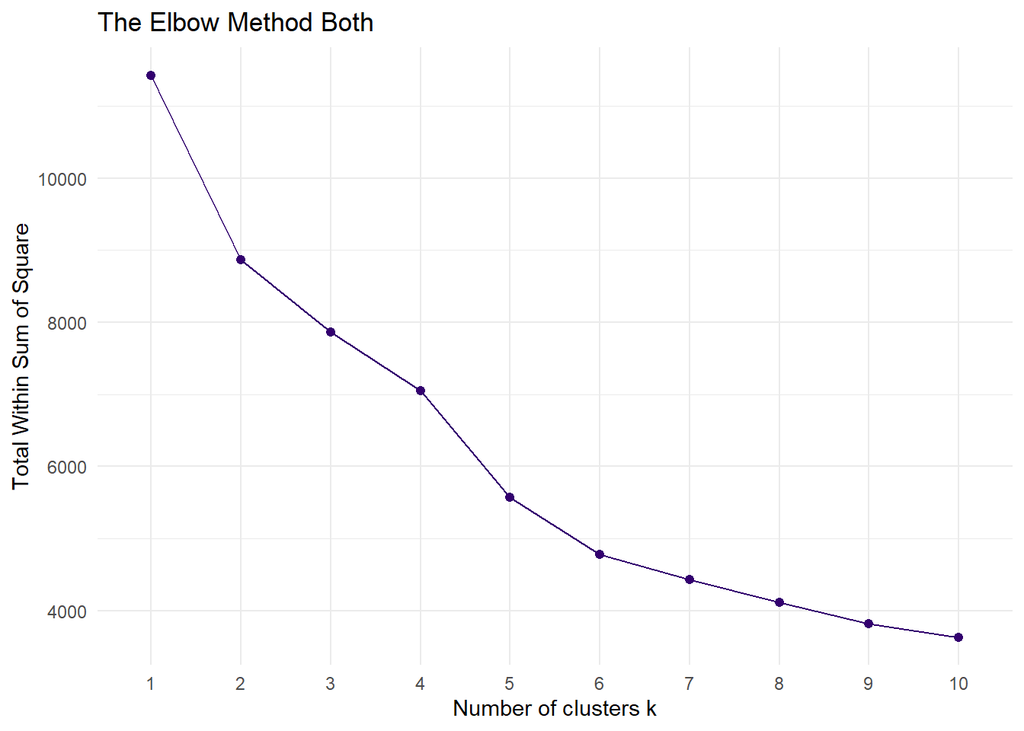

```r
#function to compute total within-cluster sum of squares
fviz_nbclust(wd_scaled, kmeans, method = "wss", k.max = 10, linecolor =   "#33006F") + theme_minimal() + ggtitle("The Elbow Method Both")
```

Since I was unable to conclusively select the number of clusters from my Elbow Test, I ran the nBClust which is a built in function that uses 30 indicies to determine the optimal number of clusters. The results are gathered by varying all combinations of number of clusters, distance measures as well as clustering methods.

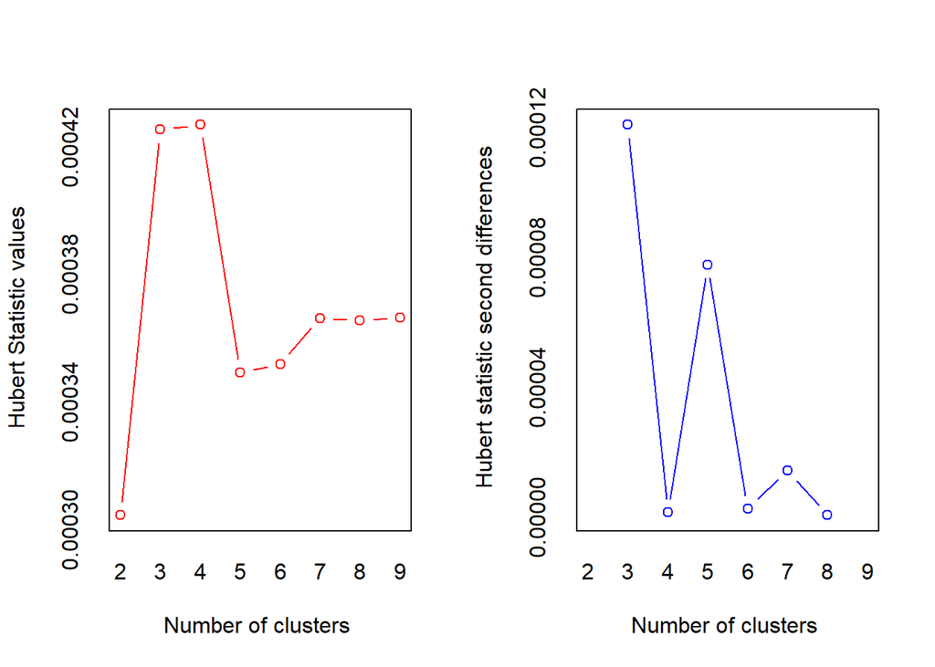

```
## *** : The Hubert index is a graphical method of determining the number of clusters.
##                 In the plot of Hubert index, we seek a significant knee that corresponds to a
##                 significant increase of the value of the measure i.e the significant peak in Hubert
##                 index second differences plot.
##
```

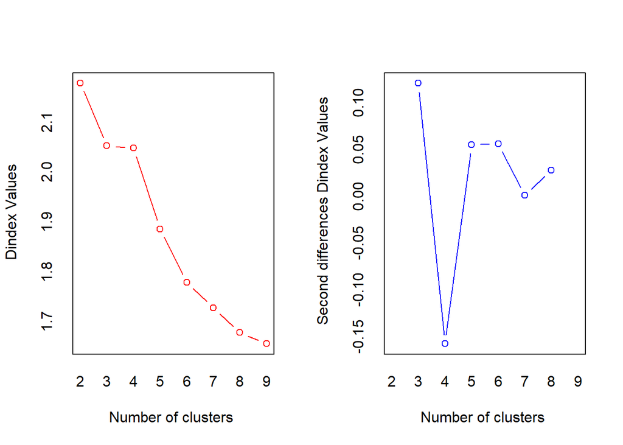

```
## *** : The D index is a graphical method of determining the number of clusters.
##                 In the plot of D index, we seek a significant knee (the significant peak in Dindex
##                 second differences plot) that corresponds to a significant increase of the value of
##                 the measure.
##
## * Among all indices:
## * 3 proposed 2 as the best number of clusters
## * 10 proposed 3 as the best number of clusters
## * 4 proposed 4 as the best number of clusters
## * 1 proposed 5 as the best number of clusters
## * 3 proposed 6 as the best number of clusters
## * 1 proposed 8 as the best number of clusters
## * 1 proposed 9 as the best number of clusters
##
##                    ***** Conclusion *****
##
## * According to the majority rule, the best number of clusters is  3
##
##
```

```r
res.nbclust <- NbClust(wd_scaled, distance = "euclidean",
                  min.nc = 2, max.nc = 9,
                  method = "complete", index ="all")
```

```
## Among all indices:
## ===================
## * 2 proposed  0 as the best number of clusters
## * 1 proposed  1 as the best number of clusters
## * 3 proposed  2 as the best number of clusters
## * 10 proposed  3 as the best number of clusters
## * 4 proposed  4 as the best number of clusters
## * 1 proposed  5 as the best number of clusters
## * 3 proposed  6 as the best number of clusters
## * 1 proposed  8 as the best number of clusters
## * 1 proposed  9 as the best number of clusters
##
## Conclusion
## =========================
## * According to the majority rule, the best number of clusters is  3 .
```

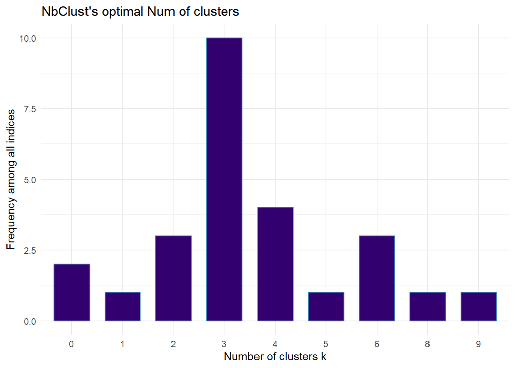

```r
factoextra::fviz_nbclust(res.nbclust,barfill="#33006F") + theme_minimal()+  ggtitle("NbClust's optimal Num of clusters")
```

Based on my testing, 3 seems to be the optimal clusters, I will now run the clusters, do some quick summary stats then bring them back to the unscaled data where I can make a little bit more sense of the outputs.

```r
p3<-c('#33006F','#C4CED4','#000000')
final_day <- kmeans(wd_scaled, 3, nstart = 25)
as.data.frame(wd_scaled) %>% mutate(Cluster = final_day$cluster) %>% group_by(Cluster) %>% summarise_all("mean") %>% kable() %>% kable_styling()
```

| Cluster | temp | pressure | humidity | wind_speed | wind_deg | clouds_all |
| --- | --- | --- | --- | --- | --- | --- |
| 1 | 0.1427504 | -5.6357044 | 0.4506134 | -0.4667929 | -0.0761636 | -0.2308871 |
| 2 | -0.7555486 | 0.1783748 | 0.7519328 | 0.4078678 | 0.2436763 | 0.9152507 |
| 3 | 0.4633926 | 0.1557248 | -0.4892247 | -0.2317084 | -0.1480257 | -0.5585978 |

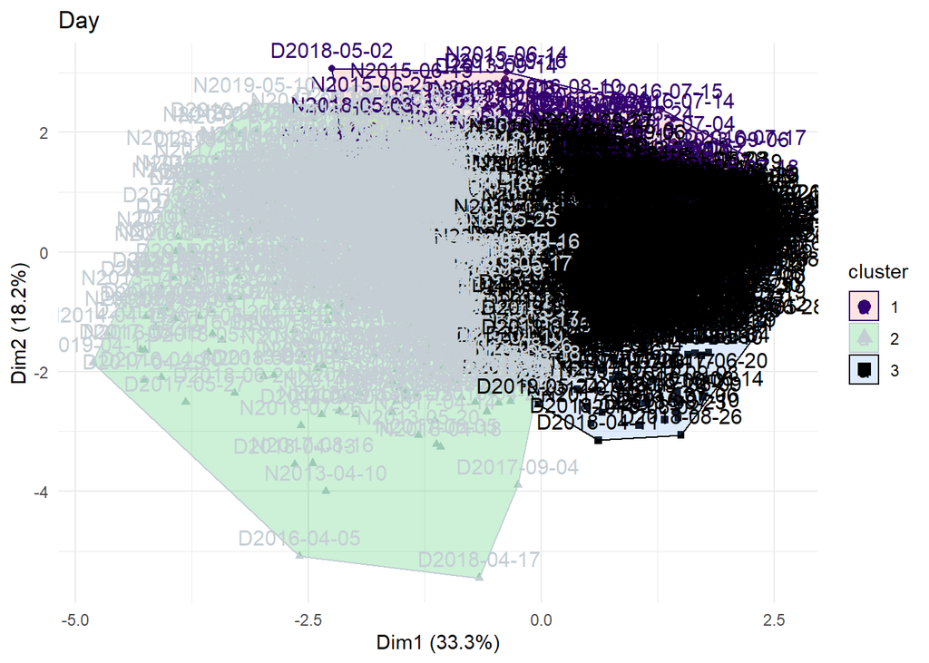

```r
fviz_cluster(final_day, data = wd_scaled)+scale_colour_manual(values = p3) + theme_minimal() + ggtitle("Day")
```

```r
new_wd <- as.data.frame(wd_scaled) %>% rownames_to_column()
as.data.frame(new_wd) %>% mutate(Cluster = final_day$cluster) %>% kable() %>% kable_styling()
```

[output not shown]

[output cut: 1875 more lines]

```r
new_wd<-new_wd%>% mutate(Cluster = final_day$cluster)
new_wd<-new_wd%>% rename(Date=rowname)
wd1<-wd1%>% rename(Date=`Day_Night||Date`)


WD_Data<-sqldf('select new_wd.Date, Cluster,wd1.temp,wd1.pressure,wd1.humidity,wd1.wind_speed,wd1.wind_deg,wd1.clouds_all from new_wd
join wd1 where new_wd.Date = wd1.Date')
WD_Data$pressure=as.numeric(WD_Data$pressure)
WD_Data$humidity=as.numeric(WD_Data$humidity)
WD_Data$wind_deg=as.numeric(WD_Data$wind_deg)
WD_Data$wind_speed=as.numeric(WD_Data$wind_speed)
WD_Data$clouds_all=as.numeric(WD_Data$clouds_all)

#View(WD_Data)
```

Seperate my Day Date column into two so I can join it to my baseball data

```r
#nchar(WD_Data$Date)
WD_Data1<-WD_Data
WD_Data1<-WD_Data1%>%mutate(Day_night=(substr(WD_Data$Date,0,1)))

WD_Data1<-WD_Data1%>%mutate(Date=(substr(WD_Data$Date,2,11)))
WD_Data<-WD_Data1

#write.csv(WD_Data, "C:/Users/ebret/Desktop/Practicum/Clustered_WD_Both.csv")
```